Dear Director,

##### Executive Summary

- Part time employment arrangements are increasing for males but remain constant for females in the sector.
- There is a decrease in part time employment for family and community services in both genders and an increase in finance, services and innovations.
- The clusters for which male part time arrangements are increasing are in education, transport and finance services and innovation.

##### Trends over time in male and female employment

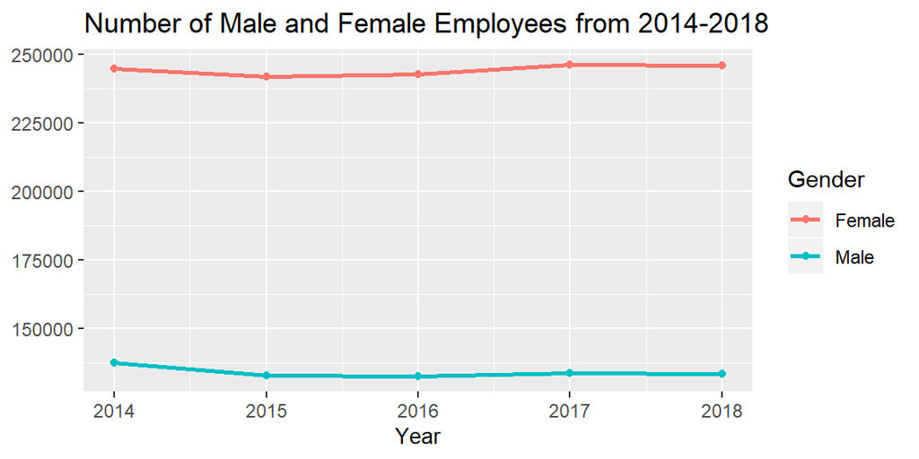

- There are significantly more female employees than males over time with the gender ratio being almost 2:1
- The number of female employees increased from 244776 in 2014 to 246049 in 2018 while male employees decreased from 137609 to 133411
- There was a 1.1% and 3.5% decrease in the number of female and male employees respectively between 2014 to 2015
- There was an average increase of 0.56% female and 0.15% male employees across the sector from 2015 to 2018

##### The current representation of part time employees in the sector and in each sector

Percentage of Part Time and Full Time Employees in 2018

| Year | Full-Time | Part-Time |
| --- | --- | --- |
| 2018 | 70.42% | 29.58% |

- In 2018, there were 70.42% full time and 29.58% part time employees in the sector.
- Across all sectors, there were more full time employees than part time employees.

##### The current representation of part time employees in the sector and in each cluster

Percentage of Part Time and Full Time Employees in 2018 by Cluster

| Year | Cluster | Full-Time | Part-Time |
| --- | --- | --- | --- |
| 2018 | Industry | 93.34 | 6.66 |
| 2018 | Treasury | 90.26 | 9.74 |
| 2018 | Justice | 89.43 | 10.57 |
| 2018 | Premier & Cabinet | 87.08 | 12.92 |
| 2018 | Family & Community Services | 85.84 | 14.16 |
| 2018 | Planning & Environment | 85.81 | 14.19 |
| 2018 | Transport | 85.77 | 14.23 |
| 2018 | Finance, Services & Innovation | 75.84 | 24.16 |
| 2018 | Health | 66.85 | 33.15 |
| 2018 | Education | 55.80 | 44.20 |

- The industry and treasury clusters contained the highest percentage of full time employees at 93% and 90% respectively.
- The education and health clusters contained the lowest percentage of full time employees at 55% and 67% respectively.

##### Changes in the representation of part time employees in the sector over time

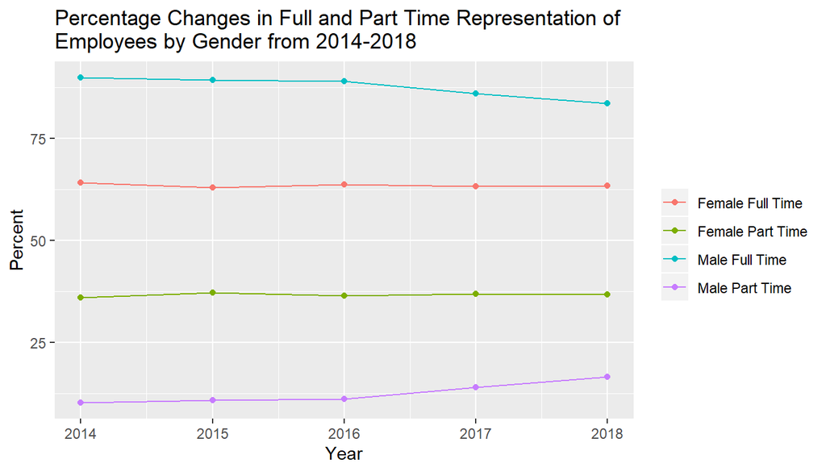

- There has been very minimal change in the percentage of females working full time versus those in part time from 2014 to 2018. The division is approximately 36% part time and 64% full time employees.
- There has been an increase in male part time employees from 10% in 2014 to 16.5% in 2018. Subsequently, there was a decrease in male full time employees from 90% to 83.5%.

##### Changes in the representation of part time employees in each cluster over time

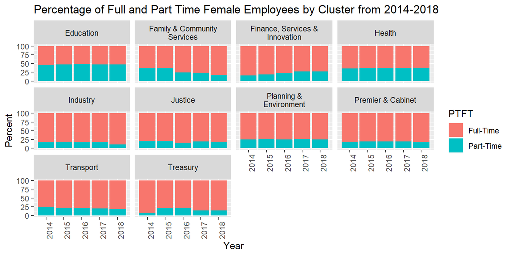

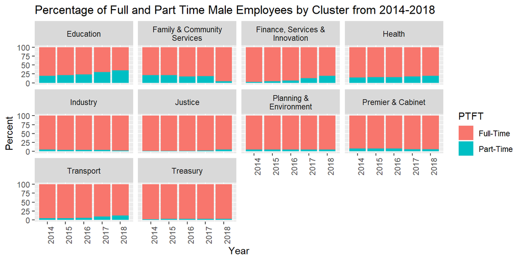